# Known Probability Distributions

Rajitha M. Silva

## Learning objectives

By the end of this lesson, students should be able to:

1. distinguish between discrete and continuous random variables;
2. identify whether a distribution is described by a pmf or a pdf;
3. recognize common probability distributions and their parameters;
4. compute probabilities using R;
5. interpret the mean and variance of each distribution.

## Random variables and probability distributions

A **random variable** is a numerical quantity whose value is determined by the outcome of a random experiment. We usually write random variables using capital letters such as $X$, $Y$, and $Z$, and possible observed values using lower-case letters such as $x$, $y$, and $z$.

Examples:

- Toss a coin once and define $X=1$ if a head appears and $X=0$ otherwise.
- Count the number of cars passing a toll booth in one hour.
- Measure the waiting time until the next customer arrives.

A **probability distribution** describes how probability is assigned to the possible values of a random variable.

## Discrete and continuous random variables

### Discrete random variables

A random variable is **discrete** if it takes countable values, usually integers.

Examples:

- number of correct answers in an MCQ test;
- number of accidents in a month;
- number of calls received in an hour.

For a discrete random variable, probabilities are described by a **probability mass function** (pmf)

$$p(x)=P(X=x).$$

A valid pmf must satisfy

$$p(x)\ge 0, \qquad \sum_x p(x)=1.$$

### Continuous random variables

A random variable is **continuous** if it can take any value in an interval of the real line.

Examples:

- height;
- weight;
- lifetime of a machine;
- waiting time.

For a continuous random variable, probabilities are described by a **probability density function** (pdf) $f(x)$. A valid pdf satisfies

$$f(x)\ge 0, \qquad \int_{-\infty}^{\infty} f(x)\,dx=1.$$

For continuous random variables,

$$P(a<X<b)=\int_a^b f(x)\,dx,$$

and $P(X=x)=0$ for any single exact value $x$.

## Summary of common distributions

| Distribution | Type | Support | Parameter(s) | Mean | Variance | R functions |
| --- | --- | --- | --- | --- | --- | --- |
| Bernoulli | Discrete | $0,1$ | $p$ | $p$ | $p(1-p)$ | `dbinom`, `pbinom`, `rbinom` |
| Binomial | Discrete | $0,1,\ldots,n$ | $n,p$ | $np$ | $np(1-p)$ | `dbinom`, `pbinom`, `rbinom` |
| Poisson | Discrete | $0,1,2,\ldots$ | $\lambda$ | $\lambda$ | $\lambda$ | `dpois`, `ppois`, `rpois` |
| Uniform | Continuous | $(a,b)$ | $a,b$ | $(a+b)/2$ | $(b-a)^2/12$ | `dunif`, `punif`, `runif` |
| Exponential | Continuous | $(0,\infty)$ | $\lambda$ | $1/\lambda$ | $1/\lambda^2$ | `dexp`, `pexp`, `rexp` |
| Normal | Continuous | $(-\infty,\infty)$ | $\mu,\sigma^2$ | $\mu$ | $\sigma^2$ | `dnorm`, `pnorm`, `rnorm` |

In R, distribution functions commonly use prefixes:

- `d`: density or mass function;
- `p`: cumulative distribution function;
- `q`: quantile function;
- `r`: random generation.

# Discrete probability distributions

## Bernoulli distribution

A random variable $X$ follows a **Bernoulli distribution** with parameter $p$, written

$$X \sim \mathrm{Bernoulli}(p),$$

if

$$P(X=1)=p, \qquad P(X=0)=1-p, \qquad 0<p<1.$$

The pmf can be written compactly as

$$P(X=x)=p^x(1-p)^{1-x}, \qquad x=0,1.$$

Mean and variance:

$$E(X)=p, \qquad \mathrm{Var}(X)=p(1-p).$$

### Example: one coin toss

Let $X=1$ if a fair coin shows head and $X=0$ otherwise. Then $X\sim \mathrm{Bernoulli}(0.5)$.

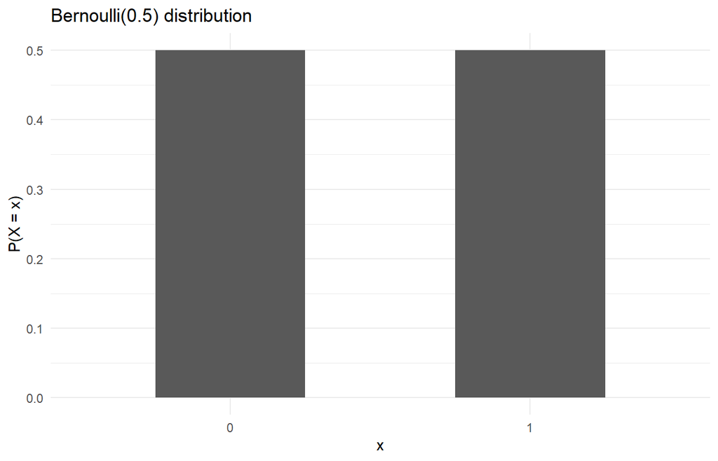

```r
p <- 0.5
bernoulli_df <- data.frame(
  x = c(0, 1),
  prob = dbinom(c(0, 1), size = 1, prob = p)
)

ggplot(bernoulli_df, aes(x = factor(x), y = prob)) +
  geom_col(width = 0.5) +
  labs(title = "Bernoulli(0.5) distribution",
       x = "x", y = "P(X = x)") +
  theme_minimal()
```

## Binomial distribution

A random variable $X$ follows a **Binomial distribution**, written

$$X\sim \mathrm{Binomial}(n,p),$$

if $X$ counts the number of successes in $n$ independent Bernoulli trials, each with success probability $p$.

The pmf is

$$P(X=x)=\binom{n}{x}p^x(1-p)^{n-x}, \qquad x=0,1,\ldots,n.$$

Mean and variance:

$$E(X)=np, \qquad \mathrm{Var}(X)=np(1-p).$$

### Example: random guessing in MCQs

Suppose there are 3 multiple-choice questions, each with 4 options and only one correct answer. A student guesses each answer independently. Let $X$ be the number of correct answers. Then

$$X\sim \mathrm{Binomial}(3,0.25).$$

```r
n <- 3
p <- 0.25
x <- 0:n
binom_df <- data.frame(
  x = x,
  prob = dbinom(x, size = n, prob = p)
)

binom_df
```

```
##   x     prob
## 1 0 0.421875
## 2 1 0.421875
## 3 2 0.140625
## 4 3 0.015625
```

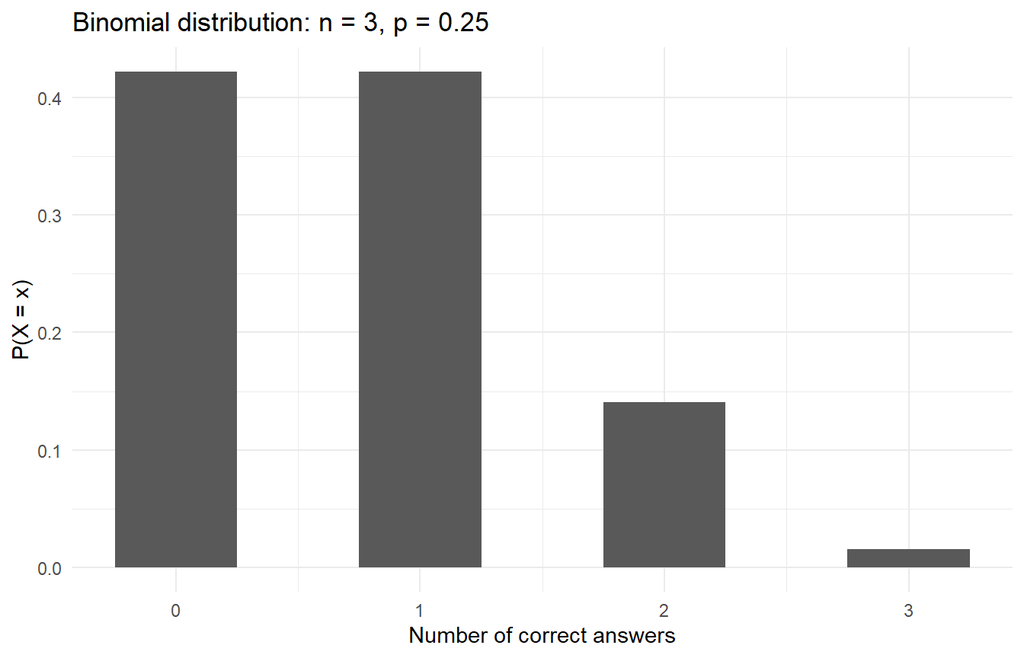

```r
ggplot(binom_df, aes(x = x, y = prob)) +
  geom_col(width = 0.5) +
  scale_x_continuous(breaks = x) +
  labs(title = "Binomial distribution: n = 3, p = 0.25",
       x = "Number of correct answers", y = "P(X = x)") +
  theme_minimal()
```

The probability of exactly two correct answers is

```r
dbinom(2, size = 3, prob = 0.25)
```

```
## [1] 0.140625
```

The probability of at least one correct answer is

```r
1 - dbinom(0, size = 3, prob = 0.25)
```

```
## [1] 0.578125
```

```r
# equivalently: 1 - pbinom(0, size = 3, prob = 0.25)
```

## Poisson distribution

A random variable $X$ follows a **Poisson distribution**, written

$$X\sim \mathrm{Poisson}(\lambda),$$

if

$$P(X=x)=\frac{e^{-\lambda}\lambda^x}{x!}, \qquad x=0,1,2,\ldots, \quad
\lambda>0.$$

Mean and variance:

$$E(X)=\lambda, \qquad \mathrm{Var}(X)=\lambda.$$

The Poisson distribution is commonly used to model counts of events occurring in a fixed interval of time or space, such as calls per hour, defects per item, or errors per page.

### Example: errors on a page

Suppose the average number of errors per page is $0.2$. Let $X$ be the number of errors on a randomly selected page. Then

$$X\sim \mathrm{Poisson}(0.2).$$

Probability of no error:

```r
dpois(0, lambda = 0.2)
```

```
## [1] 0.8187308
```

Probability of two or more errors:

```r
1 - ppois(1, lambda = 0.2)
```

```
## [1] 0.0175231
```

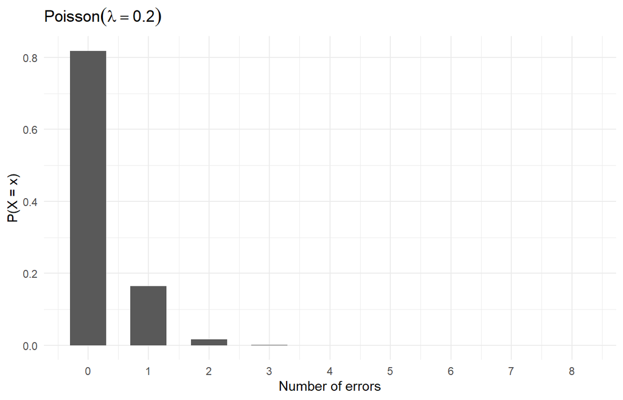

```r
lambda <- 0.2
pois_df <- data.frame(
  x = 0:8,
  prob = dpois(0:8, lambda = lambda)
)

ggplot(pois_df, aes(x = x, y = prob)) +
  geom_col(width = 0.6) +
  scale_x_continuous(breaks = 0:8) +
  labs(title = expression(Poisson(lambda == 0.2)),
       x = "Number of errors", y = "P(X = x)") +
  theme_minimal()
```

# Continuous probability distributions

## Uniform distribution

A random variable $X$ follows a **Uniform distribution** on $(a,b)$, written

$$X\sim U(a,b),$$

if its pdf is

$$f(x)=\frac{1}{b-a}, \qquad a<x<b.$$

Mean and variance:

$$E(X)=\frac{a+b}{2}, \qquad \mathrm{Var}(X)=\frac{(b-a)^2}{12}.$$

### Example

Let $X\sim U(0,10)$. Find $P(2<X<6)$.

$$P(2<X<6)=\frac{6-2}{10-0}=0.4.$$

```r
punif(6, min = 0, max = 10) - punif(2, min = 0, max = 10)
```

```
## [1] 0.4
```

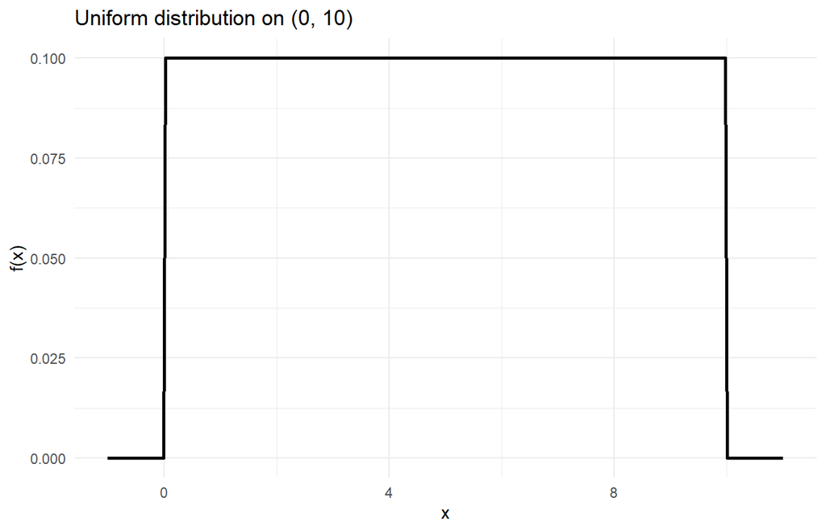

```r
unif_df <- data.frame(x = seq(-1, 11, length.out = 400)) |>
  mutate(density = dunif(x, min = 0, max = 10))

ggplot(unif_df, aes(x = x, y = density)) +
  geom_line(linewidth = 1) +
  labs(title = "Uniform distribution on (0, 10)",
       x = "x", y = "f(x)") +
  theme_minimal()
```

## Exponential distribution

A random variable $X$ follows an **Exponential distribution**, written

$$X\sim \mathrm{Exponential}(\lambda),$$

if its pdf is

$$f(x)=\lambda e^{-\lambda x}, \qquad x>0, \quad \lambda>0.$$

Mean and variance:

$$E(X)=\frac{1}{\lambda}, \qquad \mathrm{Var}(X)=\frac{1}{\lambda^2}.$$

The exponential distribution is often used to model waiting time until the next event.

Its cdf is

$$F(x)=P(X\le x)=1-e^{-\lambda x}, \qquad x>0.$$

Therefore,

$$P(X>x)=e^{-\lambda x}.$$

### Example: machine repair time

Suppose the average repair time of a machine is 0.5 hours. Since $E(X)=1/\lambda$, we have

$$\lambda=\frac{1}{0.5}=2.$$

Find $P(X>2)$.

$$P(X>2)=e^{-2(2)}=e^{-4}.$$

```r
1 - pexp(2, rate = 2)
```

```
## [1] 0.01831564
```

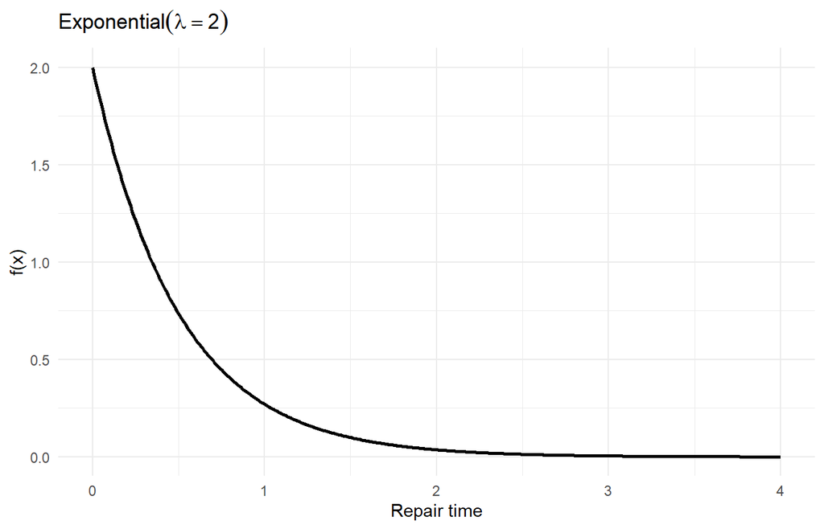

```r
exp_df <- data.frame(x = seq(0, 4, length.out = 400)) |>
  mutate(density = dexp(x, rate = 2))

ggplot(exp_df, aes(x = x, y = density)) +
  geom_line(linewidth = 1) +
  labs(title = expression(Exponential(lambda == 2)),
       x = "Repair time", y = "f(x)") +
  theme_minimal()
```

## Normal distribution

A random variable $X$ follows a **Normal distribution**, written

$$X\sim N(\mu,\sigma^2),$$

if its pdf is

$$f(x)=\frac{1}{\sigma\sqrt{2\pi}}\exp\left[-\frac{1}{2}\left(\frac{x-\mu}{\sigma}\right)^2\right],
\qquad -\infty<x<\infty.$$

Mean and variance:

$$E(X)=\mu, \qquad \mathrm{Var}(X)=\sigma^2.$$

Important characteristics:

- The curve is bell-shaped and symmetric about $\mu$.
- Mean = median = mode.
- Approximately 68.27% of observations lie within $\mu\pm \sigma$.
- Approximately 95.45% lie within $\mu\pm 2\sigma$.
- Approximately 99.73% lie within $\mu\pm 3\sigma$.

### Standard normal transformation

If

$$X\sim N(\mu,\sigma^2),$$

then

$$Z=\frac{X-\mu}{\sigma}\sim N(0,1).$$

This transformation allows probabilities for any normal random variable to be computed using the standard normal distribution.

### Example: weekly TV viewers

Suppose the number of viewers of a TV show per week, in millions, follows

$$X\sim N(29,5^2).$$

Find the probability that next week’s viewership is between 30 and 34 million.

```r
pnorm(34, mean = 29, sd = 5) - pnorm(30, mean = 29, sd = 5)
```

```
## [1] 0.262085
```

Find the probability that next week’s viewership is at least 23 million.

```r
1 - pnorm(23, mean = 29, sd = 5)
```

```
## [1] 0.8849303
```

Find the probability that next week’s viewership exceeds 40 million.

```r
1 - pnorm(40, mean = 29, sd = 5)
```

```
## [1] 0.01390345
```

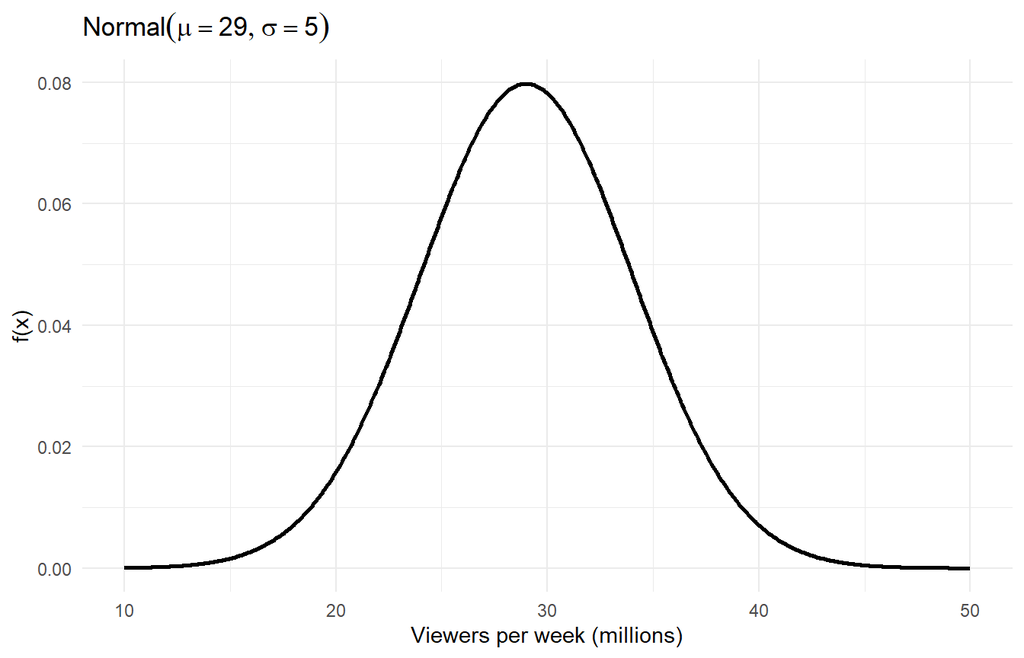

```r
norm_df <- data.frame(x = seq(10, 50, length.out = 600)) |>
  mutate(density = dnorm(x, mean = 29, sd = 5))

ggplot(norm_df, aes(x = x, y = density)) +
  geom_line(linewidth = 1) +
  labs(title = expression(Normal(mu == 29, sigma == 5)),
       x = "Viewers per week (millions)", y = "f(x)") +
  theme_minimal()
```

## Comparing distributions by simulation

Simulation helps students connect formulas with long-run frequency behavior.

```r
set.seed(502)

sim_df <- tibble(
  Bernoulli = rbinom(1000, size = 1, prob = 0.5),
  Binomial = rbinom(1000, size = 10, prob = 0.4),
  Poisson = rpois(1000, lambda = 3),
  Uniform = runif(1000, min = 0, max = 1),
  Exponential = rexp(1000, rate = 2),
  Normal = rnorm(1000, mean = 0, sd = 1)
)

summary(sim_df)
```

```
##    Bernoulli        Binomial        Poisson         Uniform
##  Min.   :0.000   Min.   :0.000   Min.   :0.000   Min.   :0.0000034
##  1st Qu.:0.000   1st Qu.:3.000   1st Qu.:2.000   1st Qu.:0.2504774
##  Median :0.000   Median :4.000   Median :3.000   Median :0.5167035
##  Mean   :0.494   Mean   :3.987   Mean   :2.942   Mean   :0.5111918
##  3rd Qu.:1.000   3rd Qu.:5.000   3rd Qu.:4.000   3rd Qu.:0.7655679
##  Max.   :1.000   Max.   :9.000   Max.   :9.000   Max.   :0.9980512
##   Exponential            Normal
##  Min.   :0.0000058   Min.   :-3.827251
##  1st Qu.:0.1420482   1st Qu.:-0.625926
##  Median :0.3388269   Median : 0.009708
##  Mean   :0.4767125   Mean   : 0.009882
##  3rd Qu.:0.6792214   3rd Qu.: 0.645336
##  Max.   :3.5063487   Max.   : 3.008563
```

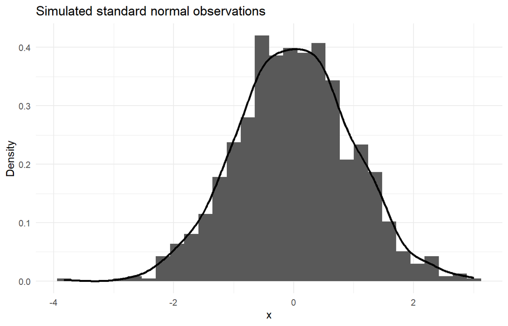

```r
ggplot(sim_df, aes(x = Normal)) +
  geom_histogram(aes(y = after_stat(density)), bins = 30) +
  geom_density(linewidth = 1) +
  labs(title = "Simulated standard normal observations",
       x = "x", y = "Density") +
  theme_minimal()
```

## Classroom discussion questions

1. What is the difference between a probability mass function and a probability density function?
2. Why is $P(X=x)=0$ for a continuous random variable?
3. When is the Binomial distribution appropriate?
4. Why does the Poisson distribution have the same mean and variance?
5. What does the parameter $\lambda$ represent in the Exponential distribution?
6. Why do we standardize a normal random variable?

## Practice problems

### Problem 1: Binomial

A student answers 8 true/false questions by guessing. Let $X$ be the number of correct answers.

1. Identify the distribution of $X$.
2. Find $P(X=5)$.
3. Find $P(X\ge 6)$.

```r
dbinom(5, size = 8, prob = 0.5)
1 - pbinom(5, size = 8, prob = 0.5)
```

### Problem 2: Poisson

A call center receives an average of 4 calls per minute. Let $X$ be the number of calls in one minute.

1. Identify the distribution of $X$.
2. Find $P(X=3)$.
3. Find $P(X>5)$.

```r
dpois(3, lambda = 4)
1 - ppois(5, lambda = 4)
```

### Problem 3: Exponential

The waiting time until the next bus follows an exponential distribution with mean 10 minutes.

1. Find $\lambda$.
2. Find the probability that the waiting time exceeds 15 minutes.

```r
rate <- 1 / 10
1 - pexp(15, rate = rate)
```

### Problem 4: Normal

Suppose exam scores follow $N(70,10^2)$.

1. Find $P(X>85)$.
2. Find $P(60<X<80)$.
3. Find the 90th percentile.

```r
1 - pnorm(85, mean = 70, sd = 10)
pnorm(80, mean = 70, sd = 10) - pnorm(60, mean = 70, sd = 10)
qnorm(0.90, mean = 70, sd = 10)
```